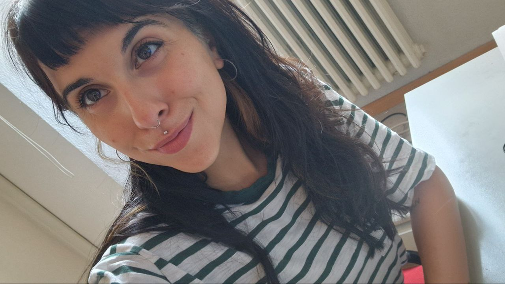

# Ottavia M. Epifania, Ph.D.

## The horror persists, and so do I

This repository hosts the PDF files of my presentations at different National and International conferences. You can also find my (fairly) updated CV and my PhD thesis.

I am a proud member of the Core Team of [Psicostat](https://psicostat.dpss.psy.unipd.it/) and you should definitely check it out :)

### 2025

AIP 2025:

EMPG 2025 presentation

Predoc Camp @ DiPSCo presentation

SIS Genova Presentation

### 2024

- Symposium at the Meeting the Association of Applied Statistics (ASA) 2024, Rome (IT): [Developing, administering and refining measurement instruments in Social Sciences](https://ottaviae.github.io/ASA2024/)
- AIP 2024, Noto: Test length doesn’t matter, it’s how you use the items that counts: An intelligent procedure for item selection in Item Response Theory
- Giornata “Prospettive interdisciplinari nella misura di competenze e capacità linguistiche in età scolare”, Padova (IT): Perché non generare test e questionari open… dal principio? Some examples
- Giornata “La psicometria tra oggi e domani: Sfide e nuovi orizzonti”, Florence (IT): L’importanza di essere significante

### 2023

- Computational and Methodological Statistics Conference 2023, Berlin (DE): When randomness opens new possibilities: Acknowledging the stimulus sampling variability in Experimental Psychology
- Meeting of the European Group of Mathematical Psychology 2023, Amsterdam (NL): matriKS: An R package for rule-based automatic generation of Raven-like matrices
- Meeting of the Association of Applied Statistics (ASA) 2023, Bologna (IT): Cut it short: A new item response theory-based approach for shortening tests
- AIP2023, Lucca:
  - Le misure in psicologia sono significanti? Il caso del test della Torre di Londra
  - matRiks: An R package for the automatic generation of Raven-like matrices

### 2021

- AIP 2021, Lecce-Ibrido 2021 (IT):
  - Less is more; Una procedura Item Response Theory per lo sviluppo di forme brevi di test
  - Risposta sbagliata! Un’analisi di Rasch per la valutazione dell’effetto del feedback sulla perfomance all’Implicit Association Test

### 2020

- Shiny demo @ eRum2020 (Online): [Scoring the Implicit Association Test has never been easier: DscoreApp](https://github.com/OttaviaE/eRum2020/blob/master/eRumShinyDemo-Epifania.Rmd)
- Poster Presentation at the useR! Conference (Online): Slides, [Poster](https://github.com/OttaviaE/useR-2020/blob/master/poster/epifania-poster.pdf), [Presentation](https://www.youtube.com/watch?v=INa426Ru40Y&list=PL4IzsxWztPdmqml-u7PvYOVLdSvD7kjby&index=6)
- AIP 2020, Online: Non separare dopo quello che hai somministrato insieme prima: Un approccio misto per l’analisi congiunta delle misure implicite
- Cognitive Science Arena (CSA), Bressanone-Brixen (IT): Filling the gap between implicit and behavior: A Rasch modeling of the Implicit Association Test **Third position as best presentation**

### 2019

- AIP 2019, Milano San Raffaele (IT): DscoreApp: Una Shiny Web application per il calcolo del *D* score

### 2018

- Meeting of the European Meeting of the Mathematical Psychology Group 2018, Genova (IT): Rasch gone mixed: A mixed model approach the Implicit Association Test Responses